# MvLA Report 2020

# Introduction

The heart data set (file heart_data.csv ) consists of nine variables, each measuring different physiological characteristics of patients at risk of heart disease. Five variables are continuous, and three are binary. One variable, Slope, is ordinal, but will be treated as continuous. The tenth variable in the data set is Class, and this denotes whether heart disease is absent (1) or present (2).

This report will consist of two sections;

1. Cluster Analysis:
   1. Identifying subsets present in the data
   2. Identifying subsets at higher risk of heart disease
2. Classification:
   1. Predicting the patients with heart disease

# Cluster Analysis

## Identifying subsets present in the data

Section Aim:

- To identify subsets of patients in the data set who have similar physiological characteristics. and determine if these subsets are at higher risk of heart disease.

### Principal Component Analysis(PCA)

Principal Component Analysis(PCA) is a dimensionality-reduction method to reduce the number of variables of a data set, while preserving as much information as possible (trade a little accuracy for simplicity). Perfoming a PCA makes it easier to identify clusters/groups present in the data. In PCA the most important component is 1 followed by 2 and so on. This is because the variance the components account for is listed in descreasing order from PC1 onwards.

I conducted a standardized PCA on this data set. The data has been standardized so that the variables with the highest variance do not dominate the PCA. If the data was not standardized the PCA would be completely dominated by the SerumCholestral varaible as this has the highest varaince (of 2671.467). Below is a graph showing the proportion of variance that can be explained by each principal component.

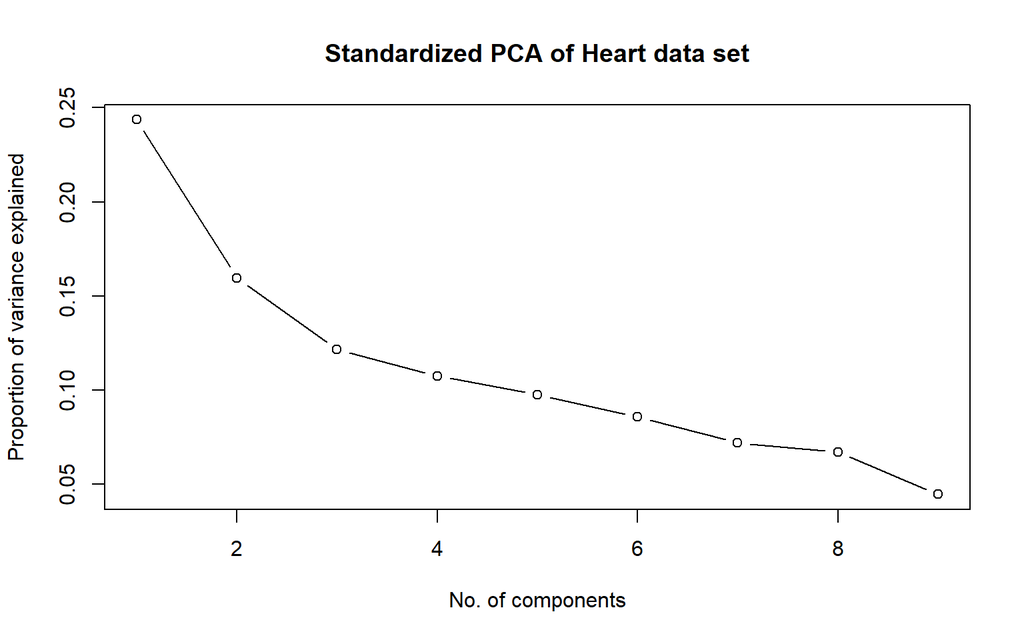

Note that the proportion of variance accounted for by PC1 is very small (0.24). When the fifth PC is included the cumulative proportion of the variance of the dataset accounted for is only 0.73. This indicates that this dataset is not very suited to PCA.

The most influential variables in the standardized PCA for PC1 were MaxHeartRate and age. This is because their coefficients or ‘loadings’ (See below) in the PC1 vector have the largest magnitude. As they have different signs this indiactes that PC1 contrasts people who have a high MaxHeartRate and are of a young age. No further valuable insights can be gained from PCA due to its poor performance when applied to this dataset.

```
                    PC1   PC2   PC3   PC4   PC5   PC6   PC7   PC8   PC9
Age               -0.46  0.28 -0.01  0.23 -0.26  0.23 -0.25  0.38 -0.57
Sex               -0.05 -0.52  0.46  0.12  0.38  0.32  0.23  0.46 -0.01
RestBloodPressure -0.26  0.36  0.21 -0.53  0.16  0.59 -0.06 -0.20  0.24
SerumCholestoral  -0.19  0.49 -0.26  0.07  0.58 -0.29  0.33  0.34  0.13
FastingBloodSugar -0.13  0.20  0.74 -0.15 -0.11 -0.57 -0.15  0.08  0.07
MaxHeartRate       0.49  0.26  0.23 -0.08  0.23  0.06  0.26 -0.24 -0.67
ExerciseInduced   -0.36 -0.34 -0.12 -0.16  0.52 -0.22 -0.43 -0.34 -0.30
Slope             -0.37 -0.24 -0.12 -0.48 -0.30 -0.17  0.62 -0.01 -0.23
 [ reached getOption("max.print") -- omitted 1 row ]
```

### Visually comparing the data

Please see the below graphs comparing the continuous variables of the dataset.

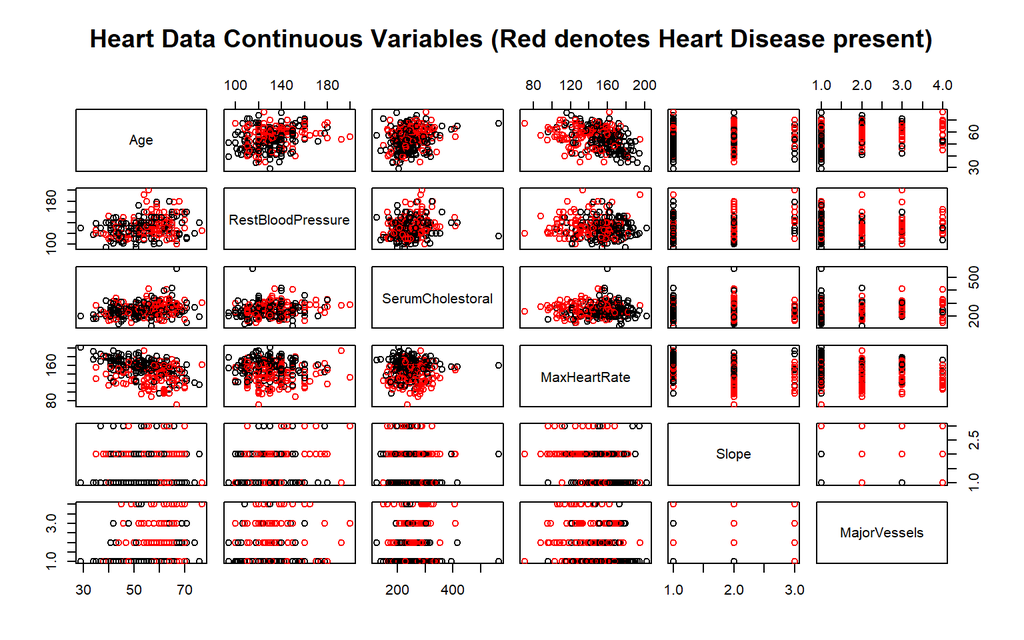

Not much can be learned from the graphs that are comparing the variables Age, RestBloodPressure and SerumCholestral to one another, but the graphs including the final 3 variables yield some interesting insights. Patients with a lower MaxHeartRate reading typically have heart disease and patients with high slope and MajorVessels readings appear to generally have heart disease. This will be discussed further later on in this report.

### Heirarchical Clustering

Hierarchical Clustering (HC) analysis groups similar observations into groups called clusters. This reveals group structure in the data.

Since this data set contains continuous and binary data the dissimilarity matrix I will be using is gower’s general dissimilarity measure. This is the recommended dissimilarity measure to use when dealing with mixed data. The linkage method I used was complete linkage, I believe this linkage method is the best for this dataset as it will join the final clusters at a much larger measure of dissimilarity ensuring that their is good internal similarity in the clusters.

A dendrogram, like the one seen below, is used to visually display the hierarchical relationships between observations. The observations that have been joined at the very bottom are most similar to one another, and then further up in the graph the more disimilar the clusters are that are being joined.

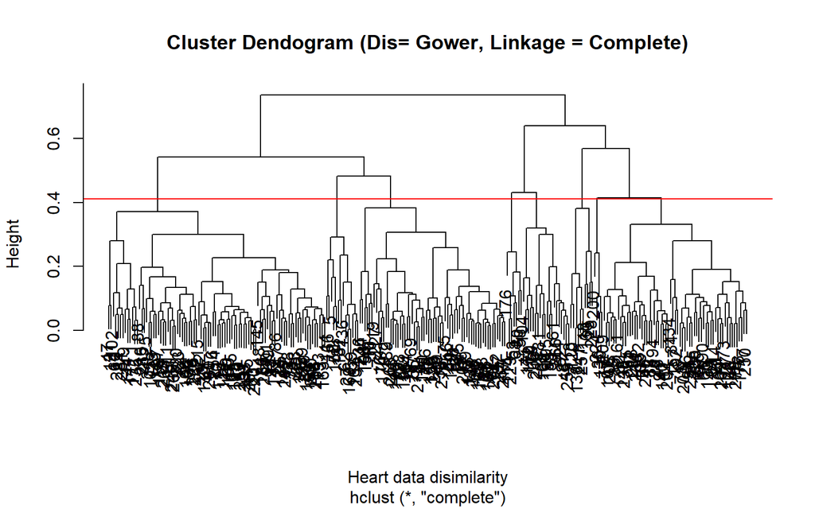

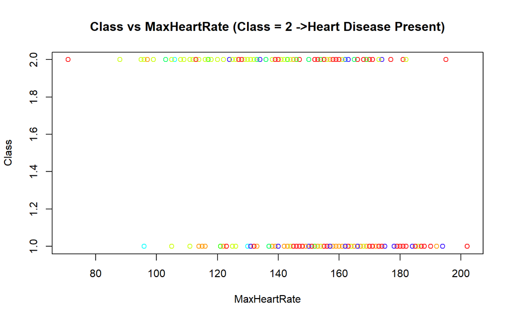

Above is a visualization of max heart rate vs class. Each of the different coulours signify clusters which were obtained from the heirarchical clustering that was performed earlier in this report. Visually not much can be deduced from this, except that the cluster being represented by the green dot appears to generally have heart disease.

```
      true_label
groups  1  2
     1 52 40
     2 54  8
     3 14 47
     4  7  7
     5  2  8
     6  5  2
     7  0  4
     8 16  4
```

In the above table we can see how many members of each of the 8 clusters have heart disease in the true_label second column and don’t have heart disease by looking in the true_label first column. From this we can see that the members of clusters 2 and 8 mainly do not have heart disease and the members of groups 3 and 7 have heart disease. It is not possible to gain any other useful insights from this table.

The below calculated Rand Index will more precisely compute how accurately these clusters reflect the true group structure of the data.

```
       RI
0.5408784
```

```
       ARI
0.08607804
```

The Rand index can have a value between 0 and 1, with 0 indicating that the two data clusterings do not agree on any pair of points and 1 indicating that the data clusterings are exactly the same.

The heirarchical data clustering result (obtained from using Glover’s dissimilairity measure, complete linkage and having 8 clusters) when compared to the true clusters classification of the data has a Rand Index score of 0.5408784. This Rand Index score was not calculated with respect to agreement by chance, so is therefore an unadjusted Rand Index.

The adjusted Rand Index, which is calculated with respect to agreement by chance, is 0.08607804. This is a very low score and suggests there is little agreement between the clusters and the real data in terms of classifying the patients with heart disease. Therefore it is not clear from heirarchical data clustering what subsets of patients are at higher risk of heart disease.

## Identifying subsets at higher risk of heart disease

Section Aim:

- To determine if any of the identified subsets are at higher risk of heart disease.

Due to the poor performance of the PCA it is not possible to identify any subsets and thus impossible to accurately determine if any of the identified subsets in PCA are at higher risk of heart disease.

The low Rand index scores which were calculated in Heirarchel Clustering analysis mean that there is little aggreement between the actual group structure of the data (i.e. group1 have heart disease & group2 don’t) and the calculated eight clusters. It was shown above that the members of clusters 2 and 8 mainly do not have heart disease and the members of groups 3 and 7 have heart disease. The remaining clusters contain a mixture of patients who have and don’t have heart disease, making it impossible to identify any common characteristics of patients who have heart disease from this analysis.

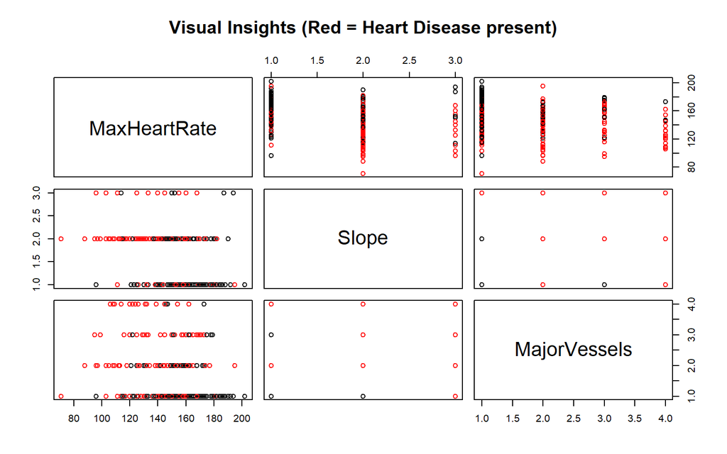

In this graph it is possible to see that patients with a MajorVessels reading of greater than or equal to two are likely to have heart disease, it is even more likely patients have heart disease if they have also recorded a reading under 140 for MaxHeartRate and a reading greater than 2 for Slope.

# Classification

The purpose of classification in this data set is to use the known data to determine if new samples have heart disease.

I will not be standardizing the data for any of the following classification methods in order to ensure that the output is easily interpreted by a wide ranging audience. For example, the group means from an unstandardized LDA are far more informative that those of a standardized LDA and easier to interpret for someone who doesn’t have extensive knowledge of standardization (If this doesn’t make sense now it will later on in this report).

## Predicting the patients with heart disease

Section Aim:

- To provide accurate predictions of patients with heart disease.

### K-Nearest Neighbours (KNN)

KNN classification is a non-parametric method of assigning group membership. It makes no assumption of the spread of the data within each class. The consequence of this is that it is not possible to measure uncertainty concerning any assignments.

This method works by comparing an observation to the k nearest datapoints and assigning that observation to the cluster who contains the most of the k datapoints it is closest to.

Choosing a value for k is very important to this method. To decide on a value for K it is important to split the known data into a training, test and validation set. This will be done in the ratio of (50%, 25%, 25%). This is a common split, because if the training set is too large the results can look better than they actually are due to a lack of samples in the validation and testing sets. The training set is used to classify the ‘unlabelled’ points of the test set. The test set is used find the value of k that is best for classification and the validation set is used to estimate the classification error of the best k identified by the test set.

```
      Value of k       The % misclassified
 [1,]            1               0.2941176
 [2,]            2               0.2794118
 [3,]            3               0.2941176
 [4,]            4               0.3676471
 [5,]            5               0.3676471
 [6,]            6               0.3970588
 [7,]            7               0.4117647
 [8,]            8               0.3676471
 [9,]            9               0.3382353
[10,]           10               0.3235294
```

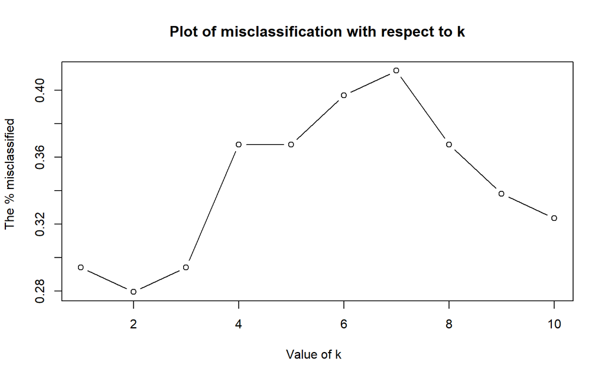

```
[1] 0.2835821
```

### Linear Discriminant Analysis (LDA)

LDA and Quadratic Discriminant Analysis (QDA) are used if it is known or assumed that there is group structure in the data. In this data set there are two groups, those who have heart disease and those who don’t.

This type of analysis reveals structure in the data which then allows for the classification of future observations. This is done by using the characteristics of labelled data in order to classify the group membership of unlabelled data.

Unlike KNN, both LDA & QDA assume the use of a distribution over the data. This then enables us to quantify the uncertainty over the structure of the data and we can consider the probability of group assignment (I.e. Is an observation highly likely to be part of the group it was assigned to or not).

As there is a large number of variables in this dataset (9) this means the data set has a high dimension. In QDA the higher the dimension the more parameters that have to be estimated (While in LDA the number of parameters is fixed). This can lead to high variance and so it is for this reason that I belive LDA is more suited to this data set.

I split 75% of the data into a training set which will be subject to LDA. We can use the result to find the prior probabilities of an observation belonging to a group and the group means for each variable. The remaining 25% of the data has been split into a test set which will be used to determine how accurate classifications made using LDA were.

Below is the prior probailities that an observation belongs to one of the groups, this is followed by the group means for each variable. From the group means, for example, we can determine that on average a person with heart disease has a MaxHeartRate recording of 138. This can be quite useful information.

Note: Group 2 has heart disease and Group 1 does not.

```
        1         2
0.5517241 0.4482759
```

```
       Age      Sex RestBloodPressure SerumCholestoral FastingBloodSugar
1 53.28571 1.517857          127.6429         243.3839          1.151786
2 56.42857 1.835165          134.4286         254.3407          1.153846
  MaxHeartRate ExerciseInduced    Slope MajorVessels
1     156.5357        1.178571 1.410714     1.312500
2     138.0330        1.549451 1.802198     2.197802
```

```
[1] 0.2089552
```

# Conclusion